# Introduction to my homework

## Answer

Gelman-Rubin method for Question 9.3

```r
Gelman.Rubin <- function(psi) {
  # psi[i,j] is the statistic psi(X[i,1:j])
  # for chain in i-th row of X
  psi <- as.matrix(psi)
  n <- ncol(psi)
  k <- nrow(psi)
  psi.means <- rowMeans(psi)     #row means
  B <- n * var(psi.means)        #between variance est.
  psi.w <- apply(psi, 1, "var")  #within variances
  W <- mean(psi.w)               #within est.
  v.hat <- W*(n-1)/n + (B/n)     #upper variance est.
  r.hat <- v.hat / W             #G-R statistic
  return(r.hat)
}

chain <- function(sigma, N, X1) {
  #generates a Metropolis chain for standard Cauchy
  #with Normal(X[t], sigma) proposal distribution
  #and starting value X1
  x <- rep(0, N)
  x[1] <- X1
  u <- runif(N)
  for (i in 2:N) {
    xt <- x[i-1]
    y <- rnorm(1, xt, sigma)    #candidate point
    r1 <- dt(y, df = 1) * dnorm(xt, y, sigma)
    r2 <- dt(xt, df = 1) * dnorm(y, xt, sigma)
    r <- r1/r2
    if (u[i] <= r) x[i] <- y else
      x[i] <- xt
  }
  return(x)
}

set.seed(12345)
sigma <- 1        #parameter of proposal distribution
k <- 4            #number of chains to generate
n <- 21000        #length of chains
b <- 12000        #burn-in length
x0 <- rnorm(k)

#generate the chains
X <- matrix(0, nrow=k, ncol=n)
for (i in 1:k)
  X[i, ] <- chain(sigma, n, x0[i])

#compute diagnostic statistics
psi <- t(apply(X, 1, cumsum))
for (i in 1:nrow(psi))
  psi[i,] <- psi[i,] / (1:ncol(psi))
cat("R=",Gelman.Rubin(psi))
```

```
## R= 1.09
```

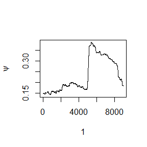

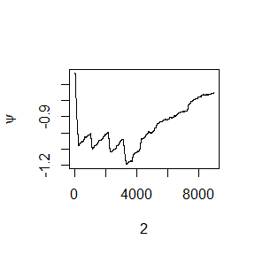

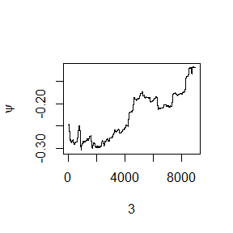

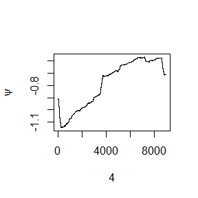

```r
#plot psi for the four chains
for (i in 1:k)
  plot(psi[i, (b+1):n], type="l",xlab=i, ylab=bquote(psi))
```

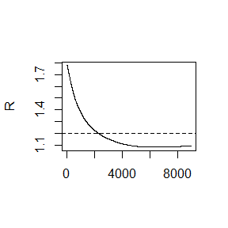

```r
#plot the sequence of R-hat statistics
rhat <- rep(0, n)
for (j in (b+1):n)
  rhat[j] <- Gelman.Rubin(psi[,1:j])
plot(rhat[(b+1):n], type="l", xlab="", ylab="R")
abline(h=1.2, lty=2)
```

分析：在time 12001 to 21000的$\hat{R}$图中表明，链在大约2100次迭代内已经大致收敛到目标分布。图中的虚线位于$\hat{R}=1.2$。  
Gelman-Rubin method for Question 9.8

```r
Gelman.Rubin <- function(psi) {
  # psi[i,j] is the statistic psi(X[i,1:j])
  # for chain in i-th row of X
  psi <- as.matrix(psi)
  n <- ncol(psi)
  k <- nrow(psi)
  psi.means <- rowMeans(psi)     #row means
  B <- n * var(psi.means)        #between variance est.
  psi.w <- apply(psi, 1, "var")  #within variances
  W <- mean(psi.w)               #within est.
  v.hat <- W*(n-1)/n + (B/n)     #upper variance est.
  r.hat <- v.hat / W             #G-R statistic
  return(r.hat)
}

chain <- function(a, b, n, N, X1, Y1) {
  #generates a Metropolis chain for target distribution
  #with the conditional distributions are Binomial(n,y) and Beta(x+a,n−x+b)
  #and starting value X1,Y1
  x <- matrix(0, N, 2)
  x[1,] <- c(X1,Y1)
  for (i in 2:N) {
    Y <- x[i-1,2]
    x[i,1] <- rbinom(1,n,Y)
    X <- x[i,1]
    x[i,2] <- rbeta(1,X+a,n-X+b)
  }
  return(x)
}

set.seed(12345)
a <- 2
b <- 4
n <- 16
k <- 4            #number of chains to generate
N <- 10000        #length of chains
burn <- 2000      #burn-in length
x0 <- sample(0:n,k,replace = TRUE)
y0 <- runif(k)

#generate the chains
X <- array(0,dim = c(N,2,k))
for (i in 1:k)
  X[ , ,i] <- chain(a, b, n, N, x0[i], y0[i])

#compute diagnostic statistics
psi <- t(apply(X, 3, cumsum))
for (i in 1:nrow(psi))
  psi[i,] <- psi[i,] / (1:ncol(psi))
print(Gelman.Rubin(psi))
```

```
## [1] 1.01
```

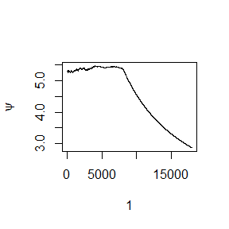

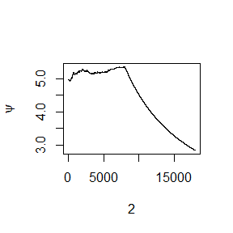

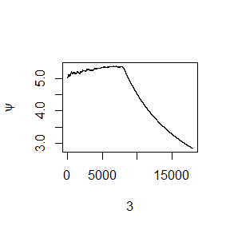

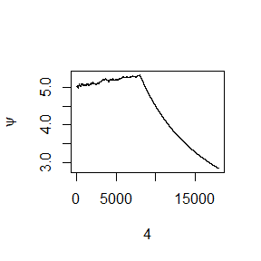

```r
#plot psi for the four chains
for (i in 1:k)
  plot(psi[i, (burn+1):(2*N)], type="l",xlab=i, ylab=bquote(psi))
```

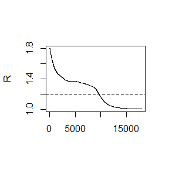

```r
#plot the sequence of R-hat statistics
rhat <- rep(0, (2*N))
for (j in (burn+1):(2*N))
  rhat[j] <- Gelman.Rubin(psi[,1:j])
plot(rhat[(burn+1):(2*N)], type="l", xlab="", ylab="R")
abline(h=1.2, lty=2)
```

分析：在time 2000 to 20000的$\hat{R}$图中表明，链在大约9000次迭代内已经大致收敛到目标分布。图中的虚线位于$\hat{R}=1.2$。

## Question

- Algorithm (continuous situation)
  - Target pdf: $f(x)$.
  - Replace $i$ and $j$ with $s$ and $r$.
  - Proposal distribution (pdf): $g(r|s)$.
  - Acceptance probability: $\alpha(s,r)=\min\{\frac{f(r)g(s|r)}{f(s)g(r|s)},1\}$.
  - Transition kernel (mixture distribution): $K(r,s)=I(s\not=r)\alpha(r,s)g(s|r)+I(s=r)[1-\int \alpha(r,s)g(s|r)]$.
  - Stationarity: $K(s,r)f(s)=K(r,s)f(r)$. Proof the Stationarity of Metropolis-Hastings sampler Algorithm in continuous situation.

## Answer

由Transition kernel (mixture distribution)可得等式：
$$K(s,r)f(s)=I(r\not=s)\alpha(s,r)g(r|s)f(s)+I(r=s)[1-\int
\alpha(s,r)g(r|s)f(s)]$$
又根据Acceptance probability: $\alpha(s,r)=\min\{\frac{f(r)g(s|r)}{f(s)g(r|s)},1\}$可得
$$\begin{align}
K(s,r)f(s) &= I(r\not=s)\alpha(s,r)g(r|s)f(s)+I(r=s)[1-\int
\alpha(s,r)g(r|s)f(s)]\\
&=
I(r\not=s)\min\{\frac{f(r)g(s|r)}{f(s)g(r|s)},1\}g(r|s)f(s)+I(r=s)[1-\int\min\{\frac{f(r)g(s|r)}{f(s)g(r|s)},1\}g(r|s)f(s)]\\
&=
I(r\not=s)\min\{f(r)g(s|r),g(r|s)f(s)\}+I(r=s)[1-\int\min\{f(r)g(s|r),g(r|s)f(s)\}]\\
&=
I(r\not=s)\min\{1,\frac{f(s)g(r|s)}{f(r)g(s|r)}\}g(s|r)f(r)+I(r=s)[1-\int\min\{1,\frac{f(s)g(r|s)}{f(r)g(s|r)}\}g(s|r)f(r)]\\
&= I(s\not=r)\alpha(r,s)g(s|r)f(r)+I(s=r)[1-\int
\alpha(r,s)g(s|r)f(r)]\\
&= K(r,s)f(r)
\end{align}$$
至此，成功证明了在continuous situation中，Metropolis-Hastings采样算法的平稳性，即$K(s,r)f(s)=K(r,s)f(r)$.

## Exercise 11.3

## Question

1. Write a function to compute the $k^{th}$ term in
   $$\sum_{k=0}^\infty
   \frac{(-1)^k}{k!2^k}\frac{||a||^{2k+2}}{(2k+1)(2k+2)}\frac{\Gamma(\frac{d+1}{2})\Gamma(k+\frac{3}{2})}{\Gamma(k+\frac{d}{2}+1)},$$
   where d ≥ 1 is an integer, $a$ is a vector in $R^d$, and $||·||$ denotes the Euclidean norm. Perform the arithmetic so that the coefficients can be computed for (almost) arbitrarily large k and d. (This sum converges for all $a \in R^d$).
2. Modify the function so that it computes and returns the sum.
3. Evaluate the sum when $a =(1,2)^T$.

## Answer

思路：先编写函数计算第k个项，然后再写一个函数用来计算整个级数的和，由于上界是无穷大，所以需要设置一个阈值来停止累加，我设置的阈值为1e-10，即当项绝对值小于1e-10时，认为其对求和的贡献可忽略不计。最后设置d的值，计算当向量a=(1,2)时的总和。需要注意的是，要满足整数d ≥ 1且可以很大，那么就需要对我们第一个函数进行修改，将gamma函数改成lgamma函数，就可以处理非常大的数值，因为它避免了直接计算阶乘，而是计算其对数值。

```r
## function to compute the kth term
compute_kth_term <- function(k, d, a) {
  norm_a <- sqrt(sum(a^2))  # 计算向量a的欧几里得范数
  kth_term <- (-1)^k / exp(lgamma(k+1)) / (2^k) * (norm_a^(2*k+2)) / ((2*k+1)*(2*k+2)) * exp(lgamma((d+1)/2) + lgamma(k + 3/2) - lgamma(k + d/2 + 1))
  return(kth_term)
}

## function to compute and return the sum
compute_sum <- function(d, a, tol = 1e-10) {
  norm_a <- sqrt(sum(a^2))
  sum <- 0
  k <- 0
  while (TRUE) {
    term <- compute_kth_term(k, d, a)
    if (abs(term) < tol) {
      break    # 设置一个阈值来确定何时停止累加，当项绝对值小于1e-10时，认为其对求和的贡献可忽略不计。
    }
    sum <- sum + term
    k <- k + 1
  }
  return(sum)
}

## Evaluate the sum when a = (1,2)
a <- c(1,2)
d <- 1     # d ≥ 1 is an integer
print(compute_sum(d,a))
```

```
## [1] 1.81
```

```r
d <- 1e4
print(compute_sum(d,a))
```

```
## [1] 0.0313
```

分析：当a=(1,2)，d=1时，总和为1.813545；当d=1e4时，总和为0.03132816。

## Exercise 11.5

## Question

Write a function to solve the equation
$$\begin{aligned}
\frac{2 \Gamma\left(\frac{k}{2}\right)}{\sqrt{\pi(k-1)}
\Gamma\left(\frac{k-1}{2}\right)}
\int_{0}^{c_{k-1}}\left(1+\frac{u^{2}}{k-1}\right)^{-k / 2} d u \\
=\frac{2 \Gamma\left(\frac{k+1}{2}\right)}{\sqrt{\pi k}
\Gamma\left(\frac{k}{2}\right)}
\int_{0}^{c_{k}}\left(1+\frac{u^{2}}{k}\right)^{-(k+1) / 2} d u
\end{aligned}$$

for $a$, where
$$c_{k}=\sqrt{\frac{a^{2} k}{k+1-a^{2}}}$$
Compare the solutions with the points $A(k)$ in Exercise 11.4.

## Answer

思路：先利用uniroot函数求例题11.4的根，然后再求11.5的根，需要注意的是当k很大的时候，计算$\Gamma(k)$会出现报错，因为算术溢出，所以需要log取对数转换一下。然后利用uniroot函数求根时，需要寻找到合适的上下界，确保两端点的正负号相反。

```r
k <- c(4:25, 100, 500, 1000)
n <- length(k)
A <- rep(0, n)
eps <- .Machine$double.eps ^ 0.25

for (i in 1:n) {
  fa <- function(a) {
    num1 <- sqrt(a ^ 2 * (k[i] - 1) / (k[i] - a ^ 2))
    num2 <- sqrt(a ^ 2 * k[i] / (k[i] + 1 - a ^ 2))
    pt(num2, k[i]) - pt(num1, k[i] - 1)
  }
  out <- uniroot(fa,lower = eps, upper = sqrt(k[i]-eps))
  A[i] <- out$root        # 11.4的根
}

B <- rep(0, n)            # 11.5的根
for (i in 1:n) {
  f <- function(x){
    return(exp(log(2) + lgamma(x/2) - (1/2)*(log(pi*(x-1))) - lgamma((x-1)/2)))
  }
  h <- function(a){
    num1 <- (f(k[i])*integrate(function(u)(1 + (u^2)/(k[i]-1))^(-k[i]/2), lower = 0, upper = sqrt((a^2)*(k[i]-1)/(k[i]-a^2)))$value)
    num2 <- (f(k[i]+1)*integrate(function(u)(1 + (u^2)/k[i])^(-(k[i]+1)/2), lower = 0, upper = sqrt((a^2)*k[i]/(k[i]+1-a^2)))$value)
    return(num1 - num2)
  }
  if(i<20)  # 为不同的k值寻找不同的上下界
    B[i] <- uniroot(h, lower = eps, upper = sqrt(k[i]-eps)-0.1)$root
  if(20<=i & i<=21)
    B[i] <- uniroot(h, lower = eps, upper = sqrt(k[i]-eps))$root
  if(22<=i & i<=23)
    B[i] <- uniroot(h, lower = 4, upper = sqrt(k[i]))$root
  if(i==24)
    B[i] <- uniroot(h, lower = sqrt(k[i])-0.03, upper = sqrt(k[i])-0.001)$root
  if(i==25)
    B[i] <- uniroot(h, lower = sqrt(k[i])-0.0037, upper = sqrt(k[i]))$root
}

knitr::kable(data.frame(k,A,B))
```

| k | A | B |
| --- | --- | --- |
| 4 | 1.49 | 1.49 |
| 5 | 1.53 | 1.53 |
| 6 | 1.56 | 1.56 |
| 7 | 1.58 | 1.58 |
| 8 | 1.60 | 1.60 |
| 9 | 1.61 | 1.61 |
| 10 | 1.62 | 1.62 |
| 11 | 1.63 | 1.63 |
| 12 | 1.64 | 1.64 |
| 13 | 1.65 | 1.65 |
| 14 | 1.65 | 1.65 |
| 15 | 1.66 | 1.66 |
| 16 | 1.66 | 1.66 |
| 17 | 1.67 | 1.67 |
| 18 | 1.67 | 1.67 |
| 19 | 1.67 | 1.67 |
| 20 | 1.68 | 1.68 |
| 21 | 1.68 | 1.68 |
| 22 | 1.68 | 1.68 |
| 23 | 4.80 | 4.80 |
| 24 | 4.90 | 4.90 |
| 25 | 5.00 | 5.00 |
| 100 | 10.00 | 10.00 |
| 500 | 22.36 | 22.36 |
| 1000 | 31.62 | 31.62 |

分析：根据表格中的数据，可以发现当k值相同时，两者的根相同。

## Question

Suppose $T_1,...,T_n$ are i.i.d. samples drawn from the exponential distribution with expectation λ. Those values greater than $\tau$ are not observed due to right censorship, so that the observed values are $Y_i = T_iI(T_i ≤ \tau) + \tau I(T_i > \tau), i = 1,...,n.$ Suppose $\tau = 1$ and the observed $Y_i$ values are as follows:
$$0.54,
0.48,0.33,0.43,1.00,1.00,0.91,1.00,0.21,0.85$$
Use the E-M algorithm to estimate λ, compare your result with the observed data MLE (note: $Y_i$ follows a mixture distribution).

## Answer

思路：首先初始化参数λ，然后通过EM算法迭代更新λ的估计值，直到收敛。在E-step中，计算每个样本是否被删失的概率，这通过指数分布的累积分布函数来实现。在M-step中，根据这些概率更新λ的估计值。最后，将EM算法的结果与MLE的结果进行比较。

```r
# 观察到的数据
Y <- c(0.54, 0.48, 0.33, 0.43, 1.00, 1.00, 0.91, 1.00, 0.21, 0.85)

# 初始化参数
n <- length(Y) # 样本数量
tau <- 1
lambda <- 1 / mean(Y[Y <= tau]) # 初始估计λ_0

# EM算法
for (i in 1:1000) {
  # E-step: 计算每个样本的潜在分类概率（是否被删失）
  Z <- pexp(Y, rate = lambda)

  # M-step: 更新lambda参数
  lambda_new <- n / sum(Y * (1 - Z) + tau * Z)

  # 检查收敛性
  if (abs(lambda_new - lambda) < 1e-6) {
    break
  }

  # 更新参数和对数似然
  lambda <- lambda_new
}

# 输出结果
cat("Estimated lambda using EM algorithm:", lambda, "\n")
```

```
## Estimated lambda using EM algorithm: 1.25
```

```r
# 计算MLE
lambda_mle <- 1 / mean(Y[Y <= tau])
cat("Estimated lambda using MLE:", lambda_mle, "\n")
```

```
## Estimated lambda using MLE: 1.48
```

分析：EM算法估计的参数值与观察数据的最大似然估计(MLE)相比，有一点差距，分析原因可能是更新λ参数的公式需要改进。

## Question

Use the simplex algorithm to solve the following problem.
Minimize $4x+2y+9z$ subject to
$$2x+y+z≤2$$
$$x−y+3z≤3$$
$$x≥0,y≥0,z≥0.$$

## Answer

思路：将约束条件和目标函数的参数写成向量形式，代入simplex()函数，因为求的是最小化，所以maxi选项选择FALSE。

```r
library(boot)
A1 <- rbind(c(2, 1, 1), c(1, -1, 3))
b1 <- c(2, 3)
a <- c(4, 2, 9)
simplex(a = a, A1 = A1, b1 = b1, maxi = FALSE)
```

```
##
## Linear Programming Results
##
## Call : simplex(a = a, A1 = A1, b1 = b1, maxi = FALSE)
##
## Minimization Problem with Objective Function Coefficients
## x1 x2 x3
##  4  2  9
##
##
## Optimal solution has the following values
## x1 x2 x3
##  0  0  0
## The optimal value of the objective  function is 0.
```

分析：由运行结果可知，当x=y=z=0时，目标函数值最小，最小值为0.

## Question

Use both for loops and lapply() to fit linear models to the mtcars using the formulas stored in this list:

```r
formulas <- list(
  mpg ~ disp,
  mpg ~ I(1 / disp),
  mpg ~ disp + wt,
  mpg ~ I(1 / disp) + wt
)
```

## Answer

思路：将formulas列表中的每一个元素代入到lm()函数中，一种方法是利用for循环，另外一种方法是直接使用lapply函数，比较两者生成的结果是否相同。

```r
library(datasets)
data(mtcars)

formulas <- list(
  mpg ~ disp,
  mpg ~ I(1 / disp),
  mpg ~ disp + wt,
  mpg ~ I(1 / disp) + wt
)

## use for loops to fit linear models to the mtcars
out1 <- vector("list", length(formulas))
for (i in seq_along(formulas)) {
  out1[[i]] <- lm(formulas[[i]], mtcars)
}

## use lapply() to fit linear models to the mtcars
out2 <- lapply(formulas, function(i) {lm(i, mtcars)})

out1
```

```
## [[1]]
##
## Call:
## lm(formula = formulas[[i]], data = mtcars)
##
## Coefficients:
## (Intercept)         disp
##     29.5999      -0.0412
##
##
## [[2]]
##
## Call:
## lm(formula = formulas[[i]], data = mtcars)
##
## Coefficients:
## (Intercept)    I(1/disp)
##        10.8       1557.7
##
##
## [[3]]
##
## Call:
## lm(formula = formulas[[i]], data = mtcars)
##
## Coefficients:
## (Intercept)         disp           wt
##     34.9606      -0.0177      -3.3508
##
##
## [[4]]
##
## Call:
## lm(formula = formulas[[i]], data = mtcars)
##
## Coefficients:
## (Intercept)    I(1/disp)           wt
##        19.0       1142.6         -1.8
```

```r
out2
```

```
## [[1]]
##
## Call:
## lm(formula = i, data = mtcars)
##
## Coefficients:
## (Intercept)         disp
##     29.5999      -0.0412
##
##
## [[2]]
##
## Call:
## lm(formula = i, data = mtcars)
##
## Coefficients:
## (Intercept)    I(1/disp)
##        10.8       1557.7
##
##
## [[3]]
##
## Call:
## lm(formula = i, data = mtcars)
##
## Coefficients:
## (Intercept)         disp           wt
##     34.9606      -0.0177      -3.3508
##
##
## [[4]]
##
## Call:
## lm(formula = i, data = mtcars)
##
## Coefficients:
## (Intercept)    I(1/disp)           wt
##        19.0       1142.6         -1.8
```

分析：使用for循环和使用lapply函数的最终结果是一致的，但是前者在迭代列表中的元素时相对冗长繁琐，而lapply函数更加简洁，避免了一段循环代码。

## Question

Fit the model mpg ~ disp to each of the bootstrap replicates of mtcars in the list below by using a for loop and lapply(). Can you do it without an anonymous function?

```r
bootstraps <- lapply(1:10, function(i) {
  rows <- sample(1:nrow(mtcars), rep = TRUE)
  mtcars[rows, ]
})
```

## Answer

思路：与上一题类似，不同之处在于使用lapply函数时不使用匿名函数，这样的话直接调用lm函数，只需在后面加上参数formula = mpg ~ disp即可。

```r
library(datasets)
data(mtcars)

set.seed(12345)
bootstraps <- lapply(1:10, function(i) {
  rows <- sample(1:nrow(mtcars), rep = TRUE)
  mtcars[rows, ]
})

## use for loops
out1 <- vector("list", length(bootstraps))
for (i in seq_along(bootstraps)) {
  out1[[i]] <- lm(mpg ~ disp, bootstraps[[i]])
}

## use lapply() without an anonymous function
out2 <- lapply(bootstraps, lm, formula = mpg ~ disp)

out1
```

```
## [[1]]
##
## Call:
## lm(formula = mpg ~ disp, data = bootstraps[[i]])
##
## Coefficients:
## (Intercept)         disp
##     29.2342      -0.0436
##
##
## [[2]]
##
## Call:
## lm(formula = mpg ~ disp, data = bootstraps[[i]])
##
## Coefficients:
## (Intercept)         disp
##     29.0705      -0.0379
##
##
## [[3]]
##
## Call:
## lm(formula = mpg ~ disp, data = bootstraps[[i]])
##
## Coefficients:
## (Intercept)         disp
##     30.0843      -0.0445
##
##
## [[4]]
##
## Call:
## lm(formula = mpg ~ disp, data = bootstraps[[i]])
##
## Coefficients:
## (Intercept)         disp
##     28.7456      -0.0365
##
##
```

[output cut: 43 more lines]

```
## lm(formula = mpg ~ disp, data = bootstraps[[i]])
##
## Coefficients:
## (Intercept)         disp
##     28.8229      -0.0389
##
##
## [[10]]
##
## Call:
## lm(formula = mpg ~ disp, data = bootstraps[[i]])
##
## Coefficients:
## (Intercept)         disp
##     31.5027      -0.0473
```

```r
out2
```

```
## [[1]]
##
## Call:
## FUN(formula = ..1, data = X[[i]])
##
## Coefficients:
## (Intercept)         disp
##     29.2342      -0.0436
##
##
## [[2]]
##
## Call:
## FUN(formula = ..1, data = X[[i]])
##
## Coefficients:
## (Intercept)         disp
##     29.0705      -0.0379
##
##
## [[3]]
##
## Call:
## FUN(formula = ..1, data = X[[i]])
##
## Coefficients:
## (Intercept)         disp
##     30.0843      -0.0445
##
##
## [[4]]
##
## Call:
## FUN(formula = ..1, data = X[[i]])
##
## Coefficients:
## (Intercept)         disp
##     28.7456      -0.0365
##
##
```

[output cut: 43 more lines]

```
## FUN(formula = ..1, data = X[[i]])
##
## Coefficients:
## (Intercept)         disp
##     28.8229      -0.0389
##
##
## [[10]]
##
## Call:
## FUN(formula = ..1, data = X[[i]])
##
## Coefficients:
## (Intercept)         disp
##     31.5027      -0.0473
```

分析：out1和out2依然相同，使用lapply函数更加简洁明了。

## Question

For each model in the previous two exercises, extract R2 using the function below.

```r
rsq <- function(mod) summary(mod)$r.squared
```

## Answer

思路：先计算模型，然后调用提供的rsq函数提取每个模型的$R^2$即可。

### First model

```r
library(datasets)
data(mtcars)

formulas <- list(
  mpg ~ disp,
  mpg ~ I(1 / disp),
  mpg ~ disp + wt,
  mpg ~ I(1 / disp) + wt
)

rsq <- function(mod) summary(mod)$r.squared

## use lapply() to fit linear models to the mtcars
out <- lapply(formulas, function(i) {rsq(lm(i, mtcars))})

out
```

```
## [[1]]
## [1] 0.718
##
## [[2]]
## [1] 0.86
##
## [[3]]
## [1] 0.781
##
## [[4]]
## [1] 0.884
```

### Second model

```r
library(datasets)
data(mtcars)

set.seed(12345)
bootstraps <- lapply(1:10, function(i) {
  rows <- sample(1:nrow(mtcars), rep = TRUE)
  mtcars[rows, ]
})

rsq <- function(mod) summary(mod)$r.squared

## use lapply() without an anonymous function
out <- lapply(bootstraps, lm, formula = mpg ~ disp)

## extract R2
res <- numeric(length(out))
for (i in 1:length(out)) {
  res[i] <- rsq(out[[i]])
}

res
```

```
##  [1] 0.763 0.688 0.744 0.659 0.657 0.730 0.825 0.754 0.754 0.728
```

分析：两种模型的$R^2$提取结果如上面代码所示。

## Question

The following code simulates the performance of a t-test for non-normal data. Use sapply() and an anonymous function to extract the p-value from every trial.

```r
trials <- replicate(
  100,
  t.test(rpois(10, 10), rpois(7, 10)),
  simplify = FALSE
)
```

Extra challenge: get rid of the anonymous function by using [[ directly.

## Answer

思路：调用sapply函数提取每一个trial的p值，省去了for循环，并且简化输出结果。

### Use sapply() and an anonymous function

```r
set.seed(12345)
trials <- replicate(
  100,
  t.test(rpois(10, 10), rpois(7, 10)),
  simplify = FALSE
)
out <- sapply(trials, function(i) {i$p.value})
out
```

```
##   [1] 0.178810 0.994262 0.064786 0.952716 0.306703 0.198225 0.272316 0.283723
##   [9] 0.415011 0.151957 0.072626 0.249014 0.773939 0.225693 0.840328 0.987492
##  [17] 0.316112 0.481741 0.457890 0.565872 0.990402 0.257905 0.538179 0.764365
##  [25] 0.845552 0.905726 0.086725 0.763640 0.088858 0.531422 0.731525 0.195574
##  [33] 0.598924 0.702134 0.147169 0.552598 0.117003 0.233189 0.127240 0.115792
##  [41] 0.317030 0.691674 0.450514 0.315344 0.073584 1.000000 0.011100 0.580715
##  [49] 0.591842 0.638287 0.283350 0.722557 0.408820 0.127118 0.000508 0.841418
##  [57] 0.624022 0.650657 0.632088 0.578419 0.052008 0.920025 0.646534 0.344836
##  [65] 0.751639 0.687324 0.134493 0.490445 0.711864 0.020395 0.342793 0.960824
##  [73] 0.111338 0.546907 0.773231 0.626304 0.298304 0.146219 0.133932 0.814393
##  [81] 0.096840 0.974930 0.808057 0.346709 0.308444 0.600936 0.984471 0.703070
##  [89] 0.678263 0.565803 0.895622 0.723438 0.431025 0.061331 0.043636 0.359298
##  [97] 0.372410 0.953012 0.503028 0.594358
```

### Use sapply() without an anonymous function

```r
set.seed(12345)
trials <- replicate(
  100,
  t.test(rpois(10, 10), rpois(7, 10)),
  simplify = FALSE
)
out <- sapply(trials, '[[',3)
out
```

```
##   [1] 0.178810 0.994262 0.064786 0.952716 0.306703 0.198225 0.272316 0.283723
##   [9] 0.415011 0.151957 0.072626 0.249014 0.773939 0.225693 0.840328 0.987492
##  [17] 0.316112 0.481741 0.457890 0.565872 0.990402 0.257905 0.538179 0.764365
##  [25] 0.845552 0.905726 0.086725 0.763640 0.088858 0.531422 0.731525 0.195574
##  [33] 0.598924 0.702134 0.147169 0.552598 0.117003 0.233189 0.127240 0.115792
##  [41] 0.317030 0.691674 0.450514 0.315344 0.073584 1.000000 0.011100 0.580715
##  [49] 0.591842 0.638287 0.283350 0.722557 0.408820 0.127118 0.000508 0.841418
##  [57] 0.624022 0.650657 0.632088 0.578419 0.052008 0.920025 0.646534 0.344836
##  [65] 0.751639 0.687324 0.134493 0.490445 0.711864 0.020395 0.342793 0.960824
##  [73] 0.111338 0.546907 0.773231 0.626304 0.298304 0.146219 0.133932 0.814393
##  [81] 0.096840 0.974930 0.808057 0.346709 0.308444 0.600936 0.984471 0.703070
##  [89] 0.678263 0.565803 0.895622 0.723438 0.431025 0.061331 0.043636 0.359298
##  [97] 0.372410 0.953012 0.503028 0.594358
```

分析：输出结果为一个包含所有p值的向量，而不是一个列表，简化了输出结果。

## Question

Implement a combination of Map() and vapply() to create an lapply() variant that iterates in parallel over all of its inputs and stores its outputs in a vector (or a matrix). What arguments should the function take?

## Answer

思路：首先需要定义一个函数，它需要接受的参数有：要应用的函数f，一系列列表（函数中需要对列表长度进行比较，长度相同才能正常调用，否则输出提示信息），传递给vapply()的其他参数，例如USE.NAMES或FUN.VALUE。

```r
my_lapply <- function(f, df, fun_value) {
  # 检查输入列表长度是否一致
  list_lengths <- sapply(list(df), length)
  if (length(unique(list_lengths)) > 1) {
    stop("All input lists must have the same length.")
  }

  # 使用 Map() 并行应用函数f到所有输入
  mapped_results <- Map(f, df)

  # 使用 vapply() 将结果转换为向量或矩阵
  final_results <- vapply(mapped_results, function(x) x, FUN.VALUE=fun_value)
  return(final_results)
}

set.seed(12345)
df <- data.frame(replicate(6,sample(c(1:10),10,rep=T)))
fun_value <- c(min=0,Qu1=0,median=0,mean=0,Qu3=0,max=0)
my_lapply(summary, df, fun_value)
```

```
##          X1    X2    X3 X4   X5    X6
## min     2.0  1.00  2.00  1  1.0  3.00
## Qu1     6.0  3.25  4.00  3  3.0  7.00
## median  7.5  6.50  6.50  4  5.0  7.00
## mean    7.0  5.70  6.30  5  5.4  7.30
## Qu3     9.5  8.00  8.75  8  8.0  9.25
## max    10.0 10.00 10.00 10 10.0 10.00
```

分析：上面的my_lapply结合了Map()和vapply()，实现了可以多个列表输入并将输出结果保存在一个矩阵中的功能。

## Question

Make a faster version of chisq.test() that only computes the chi-square test statistic when the input is two numeric vectors with no missing values. You can try simplifying chisq.test() or by coding from the mathematical definition (http://en.wikipedia.org/wiki/Pearson%27s_chi-squared_test).

## Answer

思路：依据卡方检验的数学定义公式来编写我的卡方检验函数，由于输入数据为两个相同长度的数字型向量，所以不要考虑其他类型情况，输出为一个包含卡方值、自由度、p值的列表。p值可以借助pchisq函数算出。卡方值计算公式如下：
$$x^2=\sum\frac{(A-T)^2}{T}$$
其中，A为实际值，T为理论值。

```r
my_chisq_test <- function(x, y) {
  m <- rbind(x, y)
  # Calculate row totals
  row_total <- matrix(rowSums(m))

  # Calculate column totals
  col_total <- t(matrix(colSums(m)))

  # Calculate grand total
  grand_total <- sum(m)

  # Calculate expected frequencies
  m_expected <- (row_total %*% col_total) / grand_total

  # Calculate chi-square statistic
  chi_square <- sum((m - m_expected)^2 / m_expected)
  df <- (length(row_total) - 1) * (length(col_total) - 1)
  p <- pchisq(chi_square, df = df, lower.tail = FALSE)
  return(list(chi_square = chi_square, df = df, p_value = p))
}


x <- c(1,2,3,4,5)
y <- c(6,7,8,9,10)
my_chisq_test(x,y)
```

```
## $chi_square
## [1] 1.07
##
## $df
## [1] 4
##
## $p_value
## [1] 0.899
```

分析：这个卡方检验函数只用于输入为两个相同长度的数字型向量，没有考虑其他情况，且只输出3个卡方检验统计量，所以函数体内代码较少，没有chisq.test()复杂，相对运行速度更快。

## Question

Can you make a faster version of table() for the case of an input of two integer vectors with no missing values? Can you use it to speed up your chi-square test?

## Answer

思路：先将两个向量各自的重复项去掉，用来确定table的行列数，然后用matrix函数初始化table，再利用一个循环将向量里的元素一个个对应位置填入table中。

```r
my_table <- function(x, y) {
  # Find the unique values in both vectors to determine the range for the table
  unique1 <- unique(x)
  unique2 <- unique(y)

  # Initialize the table
  # The table will have length(unique1) rows and length(unique2) columns
  table <- matrix(0, nrow = length(unique1), ncol = length(unique2),dimnames = list(unique1, unique2))

  # Fill in the table with counts
  for (i in seq_along(x)) {
    row_index <- match(x[i], unique1)
    col_index <- match(y[i], unique2)
    table[row_index, col_index] <- table[row_index, col_index] + 1
  }

  return(table)
}

x <- c(1,2,3,4,4)
y <- c('A','B','C','D','D')
my_table(x,y)
```

```
##   A B C D
## 1 1 0 0 0
## 2 0 1 0 0
## 3 0 0 1 0
## 4 0 0 0 2
```

分析：此方法生成的table与原函数table()生成的一致，且可以用来加速上一题编写的卡方检验函数，只需将原本计算row totals、column totals、grand total的代码替换成下面的代码，其余不变即可：

```r
table <- my_table(x, y)

# Calculate row and column totals
row_totals <- apply(table, 1, sum)
col_totals <- apply(table, 2, sum)
grand_total <- sum(table)
```

## Question 9.8

This example appears in [40]. Consider the bivariate density
$$f(x,y)\propto\dbinom{n}{x}y^{x+a-1}(1-y)^{n-x+b-1},\quad
x=0,1,...,n,0\leq y\leq 1.$$
It can be shown (see e.g. [23]) that for fixed a,b,n, the conditional distributions are Binomial$(n,y)$ and Beta$(x+a,n−x+b)$. Use the Gibbs sampler to generate a chain with target joint density $f(x,y)$.
* Write an Rcpp function for Exercise 9.8.
* Compare the corresponding generated random numbers with those by the R function you wrote using the function “qqplot”.
* Campare the computation time of the two functions with the function “microbenchmark”.
* Comments your results.

## Answer

```r
## R function for Exercise 9.8
Gibbs_chain_R <- function(a, b, n, N, burn, x0, y0){
  X <- matrix(0, N, 2)   #the chain, a bivariate sample
  X[1,] <- c(x0,y0)
  for (i in 2:N) {
    y <- X[i-1,2]
    X[i,1] <- rbinom(1,n,y)
    x <- X[i,1]
    X[i,2] <- rbeta(1,x+a,n-x+b)
  }
  b <- burn + 1
  x1 <- X[b:N, ]
  return(x1)
}
```

Rcpp function for Exercise 9.8

```r
#include <Rcpp.h>
using namespace Rcpp;

// [[Rcpp::export]]
NumericMatrix Gibbs_chain_C(double a, double b, int n, int N, int burn, int x0, double y0) {
  NumericMatrix X(N, 2);
  X(0,0) = x0;
  X(0,1) = y0;
  int x;
  double y;
  for(int i = 1; i < N; i++){
    y = X(i-1,1);
    X(i,0) = rbinom(1,n,y)[0];
    x = X(i,0);
    X(i,1) = rbeta(1,x+a,n-x+b)[0];
  }
  NumericMatrix x1(N-burn, 2);
  for(int i = burn; i < N; i++){
    x1(i - burn,0) = X(i,0);
    x1(i - burn,1) = X(i,1);
  }
  return x1;
}
```

Compare the corresponding generated random numbers with those by the R function you wrote using the function “qqplot”.  
Campare the computation time of the two functions with the function “microbenchmark”.

```r
Gibbs_chain_R <- function(a, b, n, N, burn, x0, y0){
  X <- matrix(0, N, 2)   #the chain, a bivariate sample
  X[1,] <- c(x0,y0)
  for (i in 2:N) {
    y <- X[i-1,2]
    X[i,1] <- rbinom(1,n,y)
    x <- X[i,1]
    X[i,2] <- rbeta(1,x+a,n-x+b)
  }
  b <- burn + 1
  x1 <- X[b:N, ]
  return(x1)
}

library(SA24168406)
library(Rcpp)
library(microbenchmark)
```

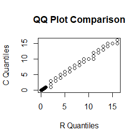

```r
set.seed(12345)
N <- 1e4                #length of chain
burn <- 1000            #burn-in length
a <- 2
b <- 4
n <- 16
x0 <- sample(0:n,1)
y0 <- runif(1)

xR <- Gibbs_chain_R(a, b, n, N, burn, x0, y0)
xC <- Gibbs_chain_C(a, b, n, N, burn, x0, y0)
qqplot(xR, xC, main = "QQ Plot Comparison", xlab="R Quantiles", ylab="C Quantiles")
```

```r
ts <- microbenchmark(gibbR=Gibbs_chain_R(a, b, n, N, burn, x0, y0),gibbC=Gibbs_chain_C(a, b, n, N, burn, x0, y0))
summary(ts)[,c(1,3,5,6)]
```

```
##    expr    lq median    uq
## 1 gibbR 24.29  25.38 27.12
## 2 gibbC  5.46   5.59  5.67
```